# Stock prices dataset

The data is of tock exchange's stock listings for each trading day of 2010 to 2016.

## Description

A brief description of columns.

- open: The opening market price of the equity symbol on the date
- high: The highest market price of the equity symbol on the date
- low: The lowest recorded market price of the equity symbol on the date
- close: The closing recorded price of the equity symbol on the date
- symbol: Symbol of the listed company
- volume: Total traded volume of the equity symbol on the date
- date: Date of record

In this assignment, we will work on the stock prices dataset named "prices.csv". The task is to create a Neural Network that predicts the closing price for a stock based on some parameters.

```python
# Initialize the random number generator
import random
random.seed(0)

# Ignore the warnings
import warnings
warnings.filterwarnings("ignore")
```

```python
from google.colab import drive
drive.mount('/content/drive')
```

## Question 1

### Load the data

- Load and read the prices.csv file using pandas

```python
# run this cell to to mount the google drive if you are using google colab
from google.colab import drive
drive.mount('/content/gdrive')
```

```python
import pandas as pd
df=pd.read_csv('/content/gdrive/MyDrive/Deep Learning/Dataset prices-1/prices.csv')
```

```python
df.head(5)
```

|  | date | symbol | open | close | low | high | volume |
| --- | --- | --- | --- | --- | --- | --- | --- |
| 0 | 2016-01-05 00:00:00 | WLTW | 123.430000 | 125.839996 | 122.309998 | 126.250000 | 2163600.0 |
| 1 | 2016-01-06 00:00:00 | WLTW | 125.239998 | 119.980003 | 119.940002 | 125.540001 | 2386400.0 |
| 2 | 2016-01-07 00:00:00 | WLTW | 116.379997 | 114.949997 | 114.930000 | 119.739998 | 2489500.0 |
| 3 | 2016-01-08 00:00:00 | WLTW | 115.480003 | 116.620003 | 113.500000 | 117.440002 | 2006300.0 |
| 4 | 2016-01-11 00:00:00 | WLTW | 117.010002 | 114.970001 | 114.089996 | 117.330002 | 1408600.0 |

## Question 2

### Check the dataset for null values and drop if there are any

```python
df.info()
```

```
<class 'pandas.core.frame.DataFrame'>
RangeIndex: 851264 entries, 0 to 851263
Data columns (total 7 columns):
 #   Column  Non-Null Count   Dtype
---  ------  --------------   -----
 0   date    851264 non-null  object
 1   symbol  851264 non-null  object
 2   open    851264 non-null  float64
 3   close   851264 non-null  float64
 4   low     851264 non-null  float64
 5   high    851264 non-null  float64
 6   volume  851264 non-null  float64
dtypes: float64(5), object(2)
memory usage: 45.5+ MB
```

```python
df.isnull().sum()
```

```
date      0
symbol    0
open      0
close     0
low       0
high      0
volume    0
dtype: int64
```

Since there is no null value so no need of droping any row

### Drop columns

- The "date", "volume" and "symbol" columns are not needed for model building. Drop these columns.

```python
df=df.drop(['date','volume','symbol'], axis=1)
```

```python
df.head(5)
```

|  | open | close | low | high |
| --- | --- | --- | --- | --- |
| 0 | 123.430000 | 125.839996 | 122.309998 | 126.250000 |
| 1 | 125.239998 | 119.980003 | 119.940002 | 125.540001 |
| 2 | 116.379997 | 114.949997 | 114.930000 | 119.739998 |
| 3 | 115.480003 | 116.620003 | 113.500000 | 117.440002 |
| 4 | 117.010002 | 114.970001 | 114.089996 | 117.330002 |

## Question 3

### Display the first 5 rows of the modified dataframe

```python
df.head(5)
```

|  | open | close | low | high |
| --- | --- | --- | --- | --- |
| 0 | 123.430000 | 125.839996 | 122.309998 | 126.250000 |
| 1 | 125.239998 | 119.980003 | 119.940002 | 125.540001 |
| 2 | 116.379997 | 114.949997 | 114.930000 | 119.739998 |
| 3 | 115.480003 | 116.620003 | 113.500000 | 117.440002 |
| 4 | 117.010002 | 114.970001 | 114.089996 | 117.330002 |

### Get features and labels from the dataset and store them in separate variables

- We are going to predict the value for the "close" column, so that will be our label. Our features will be "open", "low", "high"
- Take "open" "low", "high" columns as features
- Take "close" column as label

```python
x=df.drop(['close'],axis=1)
y=df['close']
```

```python
x.head()
```

|  | open | low | high |
| --- | --- | --- | --- |
| 0 | 123.430000 | 122.309998 | 126.250000 |
| 1 | 125.239998 | 119.940002 | 125.540001 |
| 2 | 116.379997 | 114.930000 | 119.739998 |
| 3 | 115.480003 | 113.500000 | 117.440002 |
| 4 | 117.010002 | 114.089996 | 117.330002 |

## Question 4

### Split the data into train and test sets

```python
from sklearn.model_selection import train_test_split

x_train, x_test, y_train, y_test= train_test_split(x,y,test_size=0.25, random_state=1)
```

## Question 5

### Scaling

- Scale the data (features only) using StandarScaler

```python
from sklearn.preprocessing import StandardScaler

sc=StandardScaler()

x_train= sc.fit_transform(x_train)
x_test=sc.transform(x_test)
```

## Question 6

### Convert data to NumPy array

- Convert features and labels to numpy array

```python
x_train
```

```
array([[ 0.21326333,  0.22137425,  0.21682071],
       [-0.65257955, -0.65114781, -0.65346264],
       [ 0.50742244,  0.51189267,  0.50960306],
       ...,
       [-0.33364783, -0.33247184, -0.3372008 ],
       [ 0.08341675,  0.08952911,  0.08329581],
       [-0.09477809, -0.08739226, -0.09706948]])
```

```python
y_train
```

```
414099     89.279999
556386     16.290001
496467    114.000000
786181    111.389999
513230     67.889999
             ...
491263     38.830002
791624     20.430000
470924     43.009998
491755     78.519997
128037     63.049999
Name: close, Length: 638448, dtype: float64
```

```python
y_train = y_train.to_numpy()
y_test=y_test.to_numpy()
```

```python
y_train
```

```
array([ 89.279999,  16.290001, 114.      , ...,  43.009998,  78.519997,
        63.049999])
```

## Question 7

### Define Model

- Initialize a Sequential model
- Add a Flatten layer
- Add a Dense layer with one neuron as output and 'linear' as the activation function

```python
import tensorflow as tf
model = tf.keras.models.Sequential()

model.add(tf.keras.layers.Flatten(input_shape=(3,)))
model.add(tf.keras.layers.Dense(1, activation= "linear"))
```

## Question 8

### Compile the model

- Compile the model
- Use "sgd" optimizer
- for calculating loss, use mean squared error

```python
model.compile(optimizer='sgd',loss='mse',metrics=['mae'])
```

```python
model.summary()
```

```
Model: "sequential_3"
_________________________________________________________________
Layer (type)                 Output Shape              Param #
=================================================================
flatten_2 (Flatten)          (None, 3)                 0
_________________________________________________________________
dense (Dense)                (None, 1)                 4
=================================================================
Total params: 4
Trainable params: 4
Non-trainable params: 0
_________________________________________________________________
```

## Question 9

### Fit the model

- epochs: 50
- batch size: 128
- specify that you want to use the test set as the validation data

```python
model.fit(x_train,y_train,epochs=50, batch_size=128, validation_data=(x_test,y_test))
```

```
<tensorflow.python.keras.callbacks.History at 0x7fa9602bbfd0>
```

## Question 10

### Evaluate the model

- Evaluate the model on test data

```python
results=model.evaluate(x_test,y_test, batch_size=128)
print(results)
```

```
[0.7415368556976318, 0.4195765554904938]
```

### Manual predictions

- Test the predictions on manual inputs
- We have scaled out training data, so we need to transform our custom inputs using the object of the scaler
- Example of manual input: [123.430000, 122.30999, 116.250000]

```python
import numpy as np
manual_input= np.array([123.430000, 122.30999, 116.250000])
manual_input.shape
```

```
(3,)
```

```python
manual_input=manual_input.reshape(1,3)
manual_input.shape
```

```
(1, 3)
```

```python
manual_input = sc.transform(manual_input)
manual_input
```

```
array([[0.62984918, 0.63116943, 0.53059229]])
```

```python
pred=model.predict(manual_input)
pred
```

```
array([[119.76321]], dtype=float32)
```

# Build a DNN

### Collect Fashion mnist data from tf.keras.datasets

```python
import tensorflow as tf
(trainX, trainY),(testX, testY) = tf.keras.datasets.fashion_mnist.load_data()
```

```
Downloading data from https://storage.googleapis.com/tensorflow/tf-keras-datasets/train-labels-idx1-ubyte.gz
Downloading data from https://storage.googleapis.com/tensorflow/tf-keras-datasets/train-images-idx3-ubyte.gz
Downloading data from https://storage.googleapis.com/tensorflow/tf-keras-datasets/t10k-labels-idx1-ubyte.gz
Downloading data from https://storage.googleapis.com/tensorflow/tf-keras-datasets/t10k-images-idx3-ubyte.gz
```

```python
print("Trainx Shape :",trainX.shape)
print("Testx Shape :",testX.shape)
print("Trainy Shape :",trainY.shape)
print("Testy Shape :",testY.shape)
```

```
Trainx Shape : (60000, 28, 28)
Testx Shape : (10000, 28, 28)
Trainy Shape : (60000,)
Testy Shape : (10000,)
```

```python
np.unique(trainY)
```

```
array([0, 1, 2, 3, 4, 5, 6, 7, 8, 9], dtype=uint8)
```

```python
#Here we're defining a list of the class labels that are in the dataset
class_names = ['T-shirt/top', 'Trouser', 'Pullover', 'Dress', 'Coat',
               'Sandal', 'Shirt', 'Sneaker', 'Bag', 'Ankle boot']
```

```python
import matplotlib.pyplot as plt
%matplotlib inline

#To verify that the data is in the correct format and that you're ready to build and train the network,
#let's display the first 25 images from the training set and display the class name below each image.

plt.figure(figsize=(10,10))
for i in range(25):
    plt.subplot(5,5,i+1)
    plt.xticks([])
    plt.yticks([])
    plt.grid(False)
    plt.imshow(trainX[i], cmap=plt.cm.binary)
    plt.xlabel(class_names[trainY[i]])
plt.show()
```

[output not shown]

### Convert train and test labels into one-hot vectors

```python
trainY
```

```
array([9, 0, 0, ..., 3, 0, 5], dtype=uint8)
```

```python
trainY_oh = tf.keras.utils.to_categorical(trainY,num_classes=10)
testY_oh = tf.keras.utils.to_categorical(testY,num_classes=10)
```

```python
trainY_oh.shape
```

```
(60000, 10)
```

### Initialize the model, then add a reshape layer and a BatchNormalization layer

```python
model = tf.keras.models.Sequential()

model.add(tf.keras.layers.Reshape((784,),input_shape=(28,28)))
model.add(tf.keras.layers.BatchNormalization())
```

### Add two fully connected layers with 200 and 100 neurons respectively with `relu` activations. Add a dropout layer with `p=0.25`

```python
model.add(tf.keras.layers.Dense(200, activation= "relu"))
model.add(tf.keras.layers.Dense(100, activation= "relu"))
model.add(tf.keras.layers.Dropout(0.25))
```

### Add the output layer.

- It should be a fully connected layer with 10 neurons with `softmax` activation.
- Use `categorical_crossentropy` loss and `adam` optimizer
- Add a callback such that if the validation loss doesn't decrease in two consecutive epochs, the training is stopped/
- Train the network while capturing the training progress in a variable called "history"

```python
model.add(tf.keras.layers.Dense(10,activation="softmax"))
```

```python
earlystopping= tf.keras.callbacks.EarlyStopping(monitor='val_loss', patience= 2,restore_best_weights= True)
```

```python
model.compile(optimizer='adam', loss='categorical_crossentropy',metrics=['accuracy'])
```

### Print model summary

```python
model.summary()
```

```
Model: "sequential_5"
_________________________________________________________________
Layer (type)                 Output Shape              Param #
=================================================================
reshape_1 (Reshape)          (None, 784)               0
_________________________________________________________________
batch_normalization (BatchNo (None, 784)               3136
_________________________________________________________________
dense_1 (Dense)              (None, 200)               157000
_________________________________________________________________
dense_2 (Dense)              (None, 100)               20100
_________________________________________________________________
dropout (Dropout)            (None, 100)               0
_________________________________________________________________
dense_3 (Dense)              (None, 10)                1010
=================================================================
Total params: 181,246
Trainable params: 179,678
Non-trainable params: 1,568
_________________________________________________________________
```

### Train your model, use test data as validation set

```python
history = model.fit(trainX,trainY_oh, validation_data=(testX,testY_oh), epochs=20, batch_size= 32, callbacks=earlystopping)
```

### Predict Labels

```python
y_pred= model.predict(testX)
y_pred.shape
```

```
(10000, 10)
```

```python
y_pred = model.predict_classes(testX)
y_pred
```

```
array([9, 2, 1, ..., 8, 1, 5])
```

### Print Confusion matrix

```python
from sklearn.metrics import confusion_matrix
confusion_matrix(testY,y_pred)
```

```
array([[847,   0,  18,  25,   2,   1, 100,   1,   6,   0],
       [  3, 968,   3,  22,   2,   0,   1,   0,   1,   0],
       [ 12,   1, 851,  12,  67,   1,  56,   0,   0,   0],
       [ 16,   7,  16, 912,  24,   1,  19,   0,   5,   0],
       [  0,   0, 126,  30, 783,   0,  60,   0,   1,   0],
       [  0,   0,   1,   0,   0, 954,   0,  26,   0,  19],
       [136,   1, 116,  35,  54,   0, 648,   0,  10,   0],
       [  0,   0,   0,   0,   0,  13,   0, 949,   0,  38],
       [  8,   1,   3,   5,   2,   6,   4,   5, 966,   0],
       [  1,   0,   1,   0,   0,  19,   0,  25,   0, 954]])
```

### Plot training accuracy vs validation accuracy

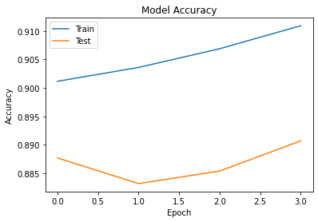

```python
import matplotlib.pyplot as plt

plt.plot(history.history['accuracy'])
plt.plot(history.history['val_accuracy'])
plt.title('Model Accuracy')
plt.ylabel('Accuracy')
plt.xlabel('Epoch')
plt.legend(['Train','Test'], loc = 'upper left')
plt.show()
```

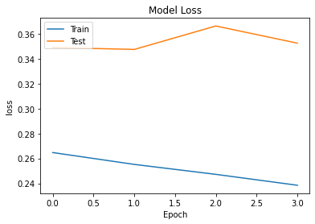

```python
plt.plot(history.history['loss'])
plt.plot(history.history['val_loss'])
plt.title('Model Loss')
plt.ylabel('loss')
plt.xlabel('Epoch')
plt.legend(['Train','Test'], loc = 'upper left')
plt.show()
```